# H&M

## Step 1: Imports and Reading Data

```python
import pandas as pd
import numpy as np
import matplotlib.pylab as plt #for visualizing dataset
import seaborn as sns
```

```python
#Read the dataset

df = pd.read_csv(r'E:\Python_2023\H&M\articles.csv')
```

## Step 2: Data Understanding

What I can do here:

- Shape of the Dataframe
- Head and tail of Dataframe
- Data types
- Description of Dataset

```python
#Shape of Dataframe
df.shape
```

```
(105542, 25)
```

The dataset has 105542 rows and 25 Columns

```python
#To see the first couple of rows of the dataset
df.head(10)
```

|  | article_id | product_code | prod_name | product_type_no | product_type_name | product_group_name | graphical_appearance_no | graphical_appearance_name | colour_group_code | colour_group_name | ... | department_name | index_code | index_name | index_group_no | index_group_name | section_no | section_name | garment_group_no | garment_group_name | detail_desc |
| --- | --- | --- | --- | --- | --- | --- | --- | --- | --- | --- | --- | --- | --- | --- | --- | --- | --- | --- | --- | --- | --- |
| 0 | 108775015 | 108775 | Strap top | 253 | Vest top | Garment Upper body | 1010016 | Solid | 9 | Black | ... | Jersey Basic | A | Ladieswear | 1 | Ladieswear | 16 | Womens Everyday Basics | 1002 | Jersey Basic | Jersey top with narrow shoulder straps. |
| 1 | 108775044 | 108775 | Strap top | 253 | Vest top | Garment Upper body | 1010016 | Solid | 10 | White | ... | Jersey Basic | A | Ladieswear | 1 | Ladieswear | 16 | Womens Everyday Basics | 1002 | Jersey Basic | Jersey top with narrow shoulder straps. |
| 2 | 108775051 | 108775 | Strap top (1) | 253 | Vest top | Garment Upper body | 1010017 | Stripe | 11 | Off White | ... | Jersey Basic | A | Ladieswear | 1 | Ladieswear | 16 | Womens Everyday Basics | 1002 | Jersey Basic | Jersey top with narrow shoulder straps. |
| 3 | 110065001 | 110065 | OP T-shirt (Idro) | 306 | Bra | Underwear | 1010016 | Solid | 9 | Black | ... | Clean Lingerie | B | Lingeries/Tights | 1 | Ladieswear | 61 | Womens Lingerie | 1017 | Under-, Nightwear | Microfibre T-shirt bra with underwired, moulde... |
| 4 | 110065002 | 110065 | OP T-shirt (Idro) | 306 | Bra | Underwear | 1010016 | Solid | 10 | White | ... | Clean Lingerie | B | Lingeries/Tights | 1 | Ladieswear | 61 | Womens Lingerie | 1017 | Under-, Nightwear | Microfibre T-shirt bra with underwired, moulde... |
| 5 | 110065011 | 110065 | OP T-shirt (Idro) | 306 | Bra | Underwear | 1010016 | Solid | 12 | Light Beige | ... | Clean Lingerie | B | Lingeries/Tights | 1 | Ladieswear | 61 | Womens Lingerie | 1017 | Under-, Nightwear | Microfibre T-shirt bra with underwired, moulde... |
| 6 | 111565001 | 111565 | 20 den 1p Stockings | 304 | Underwear Tights | Socks & Tights | 1010016 | Solid | 9 | Black | ... | Tights basic | B | Lingeries/Tights | 1 | Ladieswear | 62 | Womens Nightwear, Socks & Tigh | 1021 | Socks and Tights | Semi shiny nylon stockings with a wide, reinfo... |
| 7 | 111565003 | 111565 | 20 den 1p Stockings | 302 | Socks | Socks & Tights | 1010016 | Solid | 13 | Beige | ... | Tights basic | B | Lingeries/Tights | 1 | Ladieswear | 62 | Womens Nightwear, Socks & Tigh | 1021 | Socks and Tights | Semi shiny nylon stockings with a wide, reinfo... |
| 8 | 111586001 | 111586 | Shape Up 30 den 1p Tights | 273 | Leggings/Tights | Garment Lower body | 1010016 | Solid | 9 | Black | ... | Tights basic | B | Lingeries/Tights | 1 | Ladieswear | 62 | Womens Nightwear, Socks & Tigh | 1021 | Socks and Tights | Tights with built-in support to lift the botto... |
| 9 | 111593001 | 111593 | Support 40 den 1p Tights | 304 | Underwear Tights | Socks & Tights | 1010016 | Solid | 9 | Black | ... | Tights basic | B | Lingeries/Tights | 1 | Ladieswear | 62 | Womens Nightwear, Socks & Tigh | 1021 | Socks and Tights | Semi shiny tights that shape the tummy, thighs... |

10 rows × 25 columns

```python
#Due to the higher number of columns in the dataset, it does not show us all the columns in the "HEAD" function. To see all of them we can load this function:
pd.set_option('display.max_columns', 200)
df.head()
```

|  | article_id | product_code | prod_name | product_type_no | product_type_name | product_group_name | graphical_appearance_no | graphical_appearance_name | colour_group_code | colour_group_name | perceived_colour_value_id | perceived_colour_value_name | perceived_colour_master_id | perceived_colour_master_name | department_no | department_name | index_code | index_name | index_group_no | index_group_name | section_no | section_name | garment_group_no | garment_group_name | detail_desc |
| --- | --- | --- | --- | --- | --- | --- | --- | --- | --- | --- | --- | --- | --- | --- | --- | --- | --- | --- | --- | --- | --- | --- | --- | --- | --- |
| 0 | 108775015 | 108775 | Strap top | 253 | Vest top | Garment Upper body | 1010016 | Solid | 9 | Black | 4 | Dark | 5 | Black | 1676 | Jersey Basic | A | Ladieswear | 1 | Ladieswear | 16 | Womens Everyday Basics | 1002 | Jersey Basic | Jersey top with narrow shoulder straps. |
| 1 | 108775044 | 108775 | Strap top | 253 | Vest top | Garment Upper body | 1010016 | Solid | 10 | White | 3 | Light | 9 | White | 1676 | Jersey Basic | A | Ladieswear | 1 | Ladieswear | 16 | Womens Everyday Basics | 1002 | Jersey Basic | Jersey top with narrow shoulder straps. |
| 2 | 108775051 | 108775 | Strap top (1) | 253 | Vest top | Garment Upper body | 1010017 | Stripe | 11 | Off White | 1 | Dusty Light | 9 | White | 1676 | Jersey Basic | A | Ladieswear | 1 | Ladieswear | 16 | Womens Everyday Basics | 1002 | Jersey Basic | Jersey top with narrow shoulder straps. |
| 3 | 110065001 | 110065 | OP T-shirt (Idro) | 306 | Bra | Underwear | 1010016 | Solid | 9 | Black | 4 | Dark | 5 | Black | 1339 | Clean Lingerie | B | Lingeries/Tights | 1 | Ladieswear | 61 | Womens Lingerie | 1017 | Under-, Nightwear | Microfibre T-shirt bra with underwired, moulde... |
| 4 | 110065002 | 110065 | OP T-shirt (Idro) | 306 | Bra | Underwear | 1010016 | Solid | 10 | White | 3 | Light | 9 | White | 1339 | Clean Lingerie | B | Lingeries/Tights | 1 | Ladieswear | 61 | Womens Lingerie | 1017 | Under-, Nightwear | Microfibre T-shirt bra with underwired, moulde... |

```python
#To see all the columns name
df.columns
```

```
Index(['article_id', 'product_code', 'prod_name', 'product_type_no',
       'product_type_name', 'product_group_name', 'graphical_appearance_no',
       'graphical_appearance_name', 'colour_group_code', 'colour_group_name',
       'perceived_colour_value_id', 'perceived_colour_value_name',
       'perceived_colour_master_id', 'perceived_colour_master_name',
       'department_no', 'department_name', 'index_code', 'index_name',
       'index_group_no', 'index_group_name', 'section_no', 'section_name',
       'garment_group_no', 'garment_group_name', 'detail_desc'],
      dtype='object')
```

## Articles

- **article_id** : A unique identifier of every article.
- **product_code, prod_name** : A unique identifier of every product and its name
- **product_type, product_type_name** : The group of product_code and its name
- **graphical_appearance_no, graphical_appearance_name** : The group of graphics and its name
- **colour_group_code, colour_group_name** : The group of color and its name
- **perceived_colour_value_id, perceived_colour_value_name, perceived_colour_master_id, perceived_colour_master_name** : The added color info
- **department_no, department_name**: A unique identifier of every dep and its name
- **index_code, index_name**: A unique identifier of every index and its name
- **index_group_no, index_group_name**: A group of indices and its name
- **section_no, section_name**: A unique identifier of every section and its name
- **garment_group_no, garment_group_name**: A unique identifier of every garment and its name
- **detail_desc**: Details

```python
#To see what types of columns the dataset has
df.dtypes
```

```
article_id                       int64
product_code                     int64
prod_name                       object
product_type_no                  int64
product_type_name               object
product_group_name              object
graphical_appearance_no          int64
graphical_appearance_name       object
colour_group_code                int64
colour_group_name               object
perceived_colour_value_id        int64
perceived_colour_value_name     object
perceived_colour_master_id       int64
perceived_colour_master_name    object
department_no                    int64
department_name                 object
index_code                      object
index_name                      object
index_group_no                   int64
index_group_name                object
section_no                       int64
section_name                    object
garment_group_no                 int64
garment_group_name              object
detail_desc                     object
dtype: object
```

```python
#To see some statistical information regarding numeric columns of the dataset
df.describe()
```

|  | article_id | product_code | product_type_no | graphical_appearance_no | colour_group_code | perceived_colour_value_id | perceived_colour_master_id | department_no | index_group_no | section_no | garment_group_no |
| --- | --- | --- | --- | --- | --- | --- | --- | --- | --- | --- | --- |
| count | 1.055420e+05 | 105542.000000 | 105542.000000 | 1.055420e+05 | 105542.000000 | 105542.000000 | 105542.000000 | 105542.000000 | 105542.000000 | 105542.000000 | 105542.000000 |
| mean | 6.984246e+08 | 698424.563378 | 234.861875 | 1.009515e+06 | 32.233822 | 3.206183 | 7.807972 | 4532.777833 | 3.171534 | 42.664219 | 1010.438290 |
| std | 1.284624e+08 | 128462.384432 | 75.049308 | 2.241359e+04 | 28.086154 | 1.563839 | 5.376727 | 2712.692011 | 4.353234 | 23.260105 | 6.731023 |
| min | 1.087750e+08 | 108775.000000 | -1.000000 | -1.000000e+00 | -1.000000 | -1.000000 | -1.000000 | 1201.000000 | 1.000000 | 2.000000 | 1001.000000 |
| 25% | 6.169925e+08 | 616992.500000 | 252.000000 | 1.010008e+06 | 9.000000 | 2.000000 | 4.000000 | 1676.000000 | 1.000000 | 20.000000 | 1005.000000 |
| 50% | 7.022130e+08 | 702213.000000 | 259.000000 | 1.010016e+06 | 14.000000 | 4.000000 | 5.000000 | 4222.000000 | 2.000000 | 46.000000 | 1009.000000 |
| 75% | 7.967030e+08 | 796703.000000 | 272.000000 | 1.010016e+06 | 52.000000 | 4.000000 | 11.000000 | 7389.000000 | 4.000000 | 61.000000 | 1017.000000 |
| max | 9.594610e+08 | 959461.000000 | 762.000000 | 1.010029e+06 | 93.000000 | 7.000000 | 20.000000 | 9989.000000 | 26.000000 | 97.000000 | 1025.000000 |

```python
#To see only the numeric columns in the dataset
df.select_dtypes(include = 'int64')
```

|  | article_id | product_code | product_type_no | graphical_appearance_no | colour_group_code | perceived_colour_value_id | perceived_colour_master_id | department_no | index_group_no | section_no | garment_group_no |
| --- | --- | --- | --- | --- | --- | --- | --- | --- | --- | --- | --- |
| 0 | 108775015 | 108775 | 253 | 1010016 | 9 | 4 | 5 | 1676 | 1 | 16 | 1002 |
| 1 | 108775044 | 108775 | 253 | 1010016 | 10 | 3 | 9 | 1676 | 1 | 16 | 1002 |
| 2 | 108775051 | 108775 | 253 | 1010017 | 11 | 1 | 9 | 1676 | 1 | 16 | 1002 |
| 3 | 110065001 | 110065 | 306 | 1010016 | 9 | 4 | 5 | 1339 | 1 | 61 | 1017 |
| 4 | 110065002 | 110065 | 306 | 1010016 | 10 | 3 | 9 | 1339 | 1 | 61 | 1017 |
| ... | ... | ... | ... | ... | ... | ... | ... | ... | ... | ... | ... |
| 105537 | 953450001 | 953450 | 302 | 1010014 | 9 | 4 | 5 | 7188 | 3 | 26 | 1021 |
| 105538 | 953763001 | 953763 | 253 | 1010016 | 9 | 4 | 5 | 1919 | 1 | 2 | 1005 |
| 105539 | 956217002 | 956217 | 265 | 1010016 | 9 | 4 | 5 | 1641 | 1 | 18 | 1005 |
| 105540 | 957375001 | 957375 | 72 | 1010016 | 9 | 4 | 5 | 3946 | 2 | 52 | 1019 |
| 105541 | 959461001 | 959461 | 265 | 1010016 | 11 | 1 | 9 | 1641 | 1 | 18 | 1005 |

105542 rows × 11 columns

```python
#To see the columns information
df.info()
```

```
<class 'pandas.core.frame.DataFrame'>
RangeIndex: 105542 entries, 0 to 105541
Data columns (total 25 columns):
 #   Column                        Non-Null Count   Dtype
---  ------                        --------------   -----
 0   article_id                    105542 non-null  int64
 1   product_code                  105542 non-null  int64
 2   prod_name                     105542 non-null  object
 3   product_type_no               105542 non-null  int64
 4   product_type_name             105542 non-null  object
 5   product_group_name            105542 non-null  object
 6   graphical_appearance_no       105542 non-null  int64
 7   graphical_appearance_name     105542 non-null  object
 8   colour_group_code             105542 non-null  int64
 9   colour_group_name             105542 non-null  object
```

[output cut: 17 more lines]

## Step 3: Data Preparation/Cleaning

```python
##Dropping some columns

df = df[[#'article_id',
    'product_code', 'prod_name',
    #'product_type_no',
       'product_type_name', 'product_group_name',
    #'graphical_appearance_no', 'graphical_appearance_name', 'colour_group_code',
    'colour_group_name',
       #'perceived_colour_value_id', 'perceived_colour_value_name',
       #'perceived_colour_master_id', 'perceived_colour_master_name',
       #'department_no', 'department_name', 'index_code',
    'index_name',
       #'index_group_no',
    'index_group_name']].copy() #".copy()" function allows you to have no connection from the original dataset
    #'section_no', 'section_name', 'garment_group_no', 'garment_group_name', 'detail_desc'
```

```python
##Reanme column name
df = df.rename(columns = {'product_code':'Product_Code',
                    'prod_name':'Product_Name',
                    'product_type_name':'Product_Type_Name',
                    'product_group_name':'Product_Group_Name',
                    'colour_group_name':'Colour_Group_Name',
                    'index_name':'Index_Name',
                    'index_group_name':'Index_Group_Name'})
```

```python
#Examining null or missing values in the dataset

df.isna()
```

|  | Product_Code | Product_Name | Product_Type_Name | Product_Group_Name | Colour_Group_Name | Index_Name | Index_Group_Name |
| --- | --- | --- | --- | --- | --- | --- | --- |
| 0 | False | False | False | False | False | False | False |
| 1 | False | False | False | False | False | False | False |
| 2 | False | False | False | False | False | False | False |
| 3 | False | False | False | False | False | False | False |
| 4 | False | False | False | False | False | False | False |
| ... | ... | ... | ... | ... | ... | ... | ... |
| 105537 | False | False | False | False | False | False | False |
| 105538 | False | False | False | False | False | False | False |
| 105539 | False | False | False | False | False | False | False |
| 105540 | False | False | False | False | False | False | False |
| 105541 | False | False | False | False | False | False | False |

105542 rows × 7 columns

```python
df.isna().sum()
```

```
Product_Code          0
Product_Name          0
Product_Type_Name     0
Product_Group_Name    0
Colour_Group_Name     0
Index_Name            0
Index_Group_Name      0
dtype: int64
```

```python
#Another way of finding missing data by creating function:

def missing_data(data):
    total = data.isnull().sum().sort_values(ascending = False)
    percent = ((data.isnull().sum()/data.isnull().count())*100).sort_values(ascending = False)
    return pd.concat([total, percent], axis = 1, keys = ['Total', 'Percent'])

missing_data(df)
```

[output not shown]

there is no null or missing values

```python
# .duplicated() method is used to identify duplicate rows in a DataFrame
df.loc[df.duplicated(subset=['Product_Code'])]
```

|  | Product_Code | Product_Name | Product_Type_Name | Product_Group_Name | Colour_Group_Name | Index_Name | Index_Group_Name |
| --- | --- | --- | --- | --- | --- | --- | --- |
| 1 | 108775 | Strap top | Vest top | Garment Upper body | White | Ladieswear | Ladieswear |
| 2 | 108775 | Strap top (1) | Vest top | Garment Upper body | Off White | Ladieswear | Ladieswear |
| 4 | 110065 | OP T-shirt (Idro) | Bra | Underwear | White | Lingeries/Tights | Ladieswear |
| 5 | 110065 | OP T-shirt (Idro) | Bra | Underwear | Light Beige | Lingeries/Tights | Ladieswear |
| 7 | 111565 | 20 den 1p Stockings | Socks | Socks & Tights | Beige | Lingeries/Tights | Ladieswear |
| ... | ... | ... | ... | ... | ... | ... | ... |
| 105505 | 946748 | Louie solid | Sweater | Garment Upper body | Light Pink | Ladieswear | Ladieswear |
| 105508 | 946764 | Fred knitted cardigan | Cardigan | Garment Upper body | Light Beige | Ladieswear | Ladieswear |
| 105511 | 946827 | Sunshine skirt paperbag | Skirt | Garment Lower body | Greenish Khaki | Ladieswear | Ladieswear |
| 105523 | 948152 | BELL w. skirt set | Garment Set | Garment Full body | Green | Children Sizes 92-140 | Baby/Children |
| 105531 | 949551 | Virgo sweater fast buy | Sweater | Garment Upper body | Pink | Divided | Divided |

58318 rows × 7 columns

```python
#An example of checking duplicate
df.query('Product_Code == "214844"')
```

|  | Product_Code | Product_Name | Product_Type_Name | Product_Group_Name | Colour_Group_Name | Index_Name | Index_Group_Name |
| --- | --- | --- | --- | --- | --- | --- | --- |

```python
pd.value_counts(df['Index_Group_Name'])
```

```
Ladieswear       39737
Baby/Children    34711
Divided          15149
Menswear         12553
Sport             3392
Name: Index_Group_Name, dtype: int64
```

## Step 4: Data analysing with different charts

Trying to answer this questions:

- which product type is the most in the product type? #Same question will be tried for other columns also
- what and how many of the product types are there in different product group?
- How many articles are there in different product group and product type?

```python
articles_df = pd.read_csv(r'E:\Python_2023\H&M\articles.csv')
```

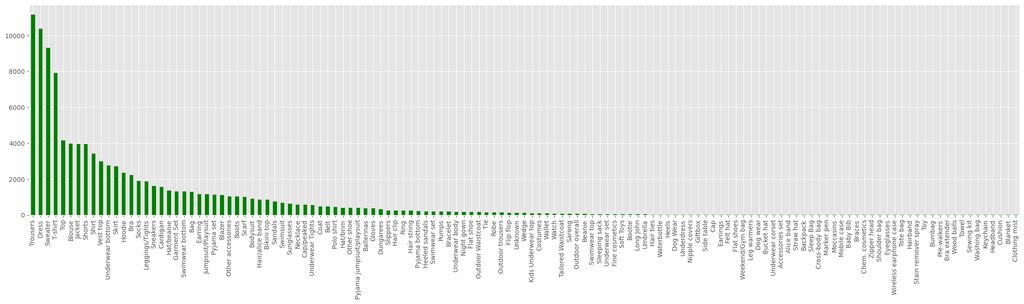

```python
#What are the product types and which is the most product type
articles_df['product_type_name'].value_counts().plot(kind = 'bar', color = 'green', figsize = (28,6))
```

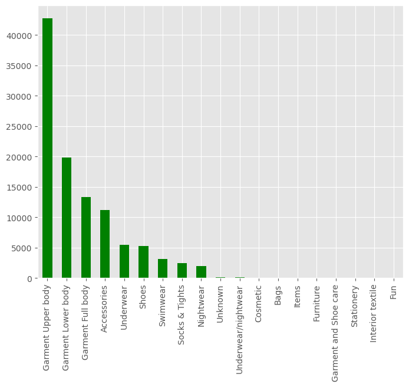

```python
articles_df['product_group_name'].value_counts().plot(kind = 'bar', color = 'green', width = 0.5, figsize = (8,6))
```

"Garment upper body" is the most product group name

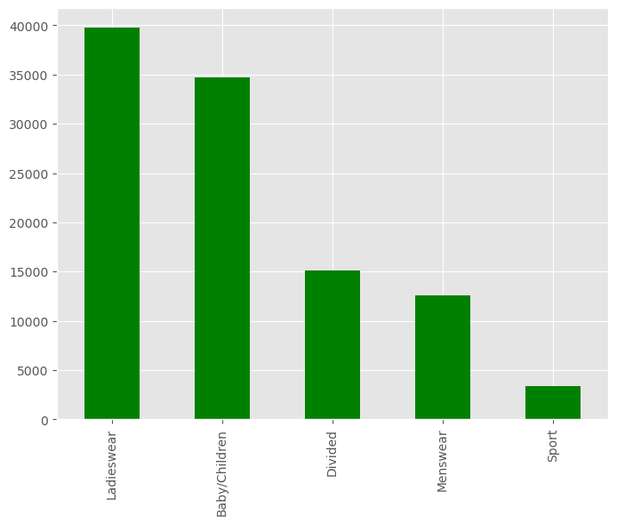

```python
articles_df['index_group_name'].value_counts().plot(kind = 'bar', color = 'green', width = 0.5, figsize = (8,6))
```

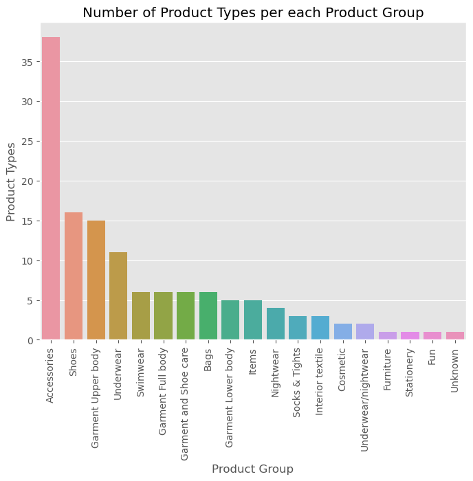

```python
##what and how many of the product types are there in different product group?

# .nunique() method in Pandas is used to count the number of unique values in a DataFrame or Series.
#It returns the count of distinct, non-null values present in the data.

temp = articles_df.groupby(["product_group_name"])["product_type_name"].nunique()
df = pd.DataFrame({'Product Group': temp.index,
                   'Product Types': temp.values
                  })
df = df.sort_values(['Product Types'], ascending = False)
plt.figure(figsize = (8,6))
plt.title('Number of Product Types per each Product Group')
sns.set_color_codes("muted")
s = sns.barplot(x = 'Product Group', y="Product Types", data=df)
s.set_xticklabels(s.get_xticklabels(),rotation=90)
locs, labels = plt.xticks()
plt.show()
```

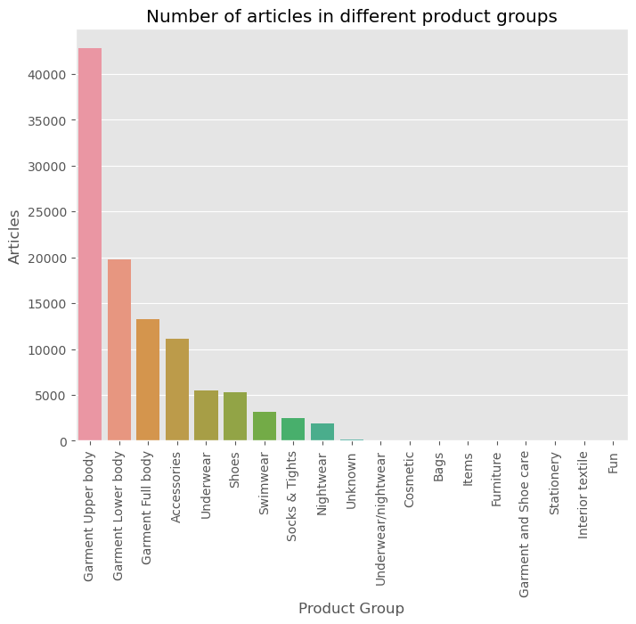

```python
##How many articles are there in different product group

temp = articles_df.groupby(['product_group_name'])['article_id'].nunique()
df = pd.DataFrame({'Product Group': temp.index,
                   'Articles': temp.values
                  })
df = df.sort_values(['Articles'], ascending = False)
plt.figure(figsize = (8,6))
plt.title('Number of articles in different product groups')
sns.set_color_codes('pastel')
s = sns.barplot(x = 'Product Group', y = 'Articles', data = df)
s.set_xticklabels(s.get_xticklabels(), rotation = 90)
locs, labels = plt.xticks()
plt.show()
```

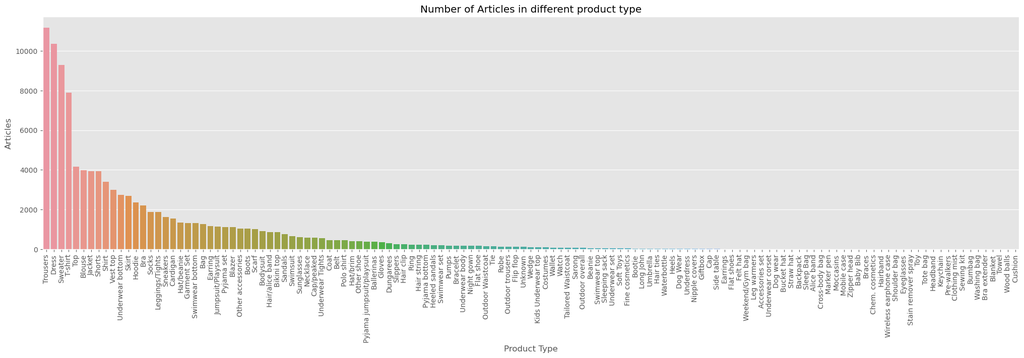

```python
##How many articles are there in different product type

temp = articles_df.groupby(['product_type_name'])['article_id'].nunique()
df = pd.DataFrame({'Product Type': temp.index, 'Articles': temp.values})
df = df.sort_values(['Articles'], ascending = False)
plt.figure(figsize = (25,6))
plt.title("Number of Articles in different product type")
sns.set_color_codes("pastel")
s = sns.barplot(x = 'Product Type', y = 'Articles', data = df)
s.set_xticklabels(s.get_xticklabels(), rotation = 90)
locs, labels = plt.xticks()
plt.show()
```

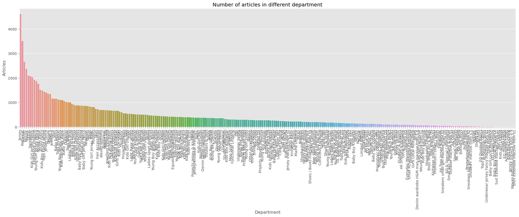

```python
##How many articles are there in different department

temp = articles_df.groupby(['department_name'])['article_id'].nunique()
df = pd.DataFrame({"Department": temp.index, "Articles": temp.values})
df = df.sort_values(['Articles'], ascending = False)
plt.figure(figsize = (25,6))
plt.title("Number of articles in different department")
sns.set_color_codes("pastel")
s = sns.barplot(x = "Department", y = "Articles", data =df)
s.set_xticklabels(s.get_xticklabels(), rotation = 90)
locs, labels = plt.xticks()
plt.show()
```

```python
articles_df["department_name"].value_counts()
```

```
Jersey                             4604
Knitwear                           3503
Trouser                            2655
Blouse                             2362
Dress                              2087
                                   ...
Woven bottoms inactive from S.7       1
Jersey inactive from S.6              1
EQ Divided Blue                       1
Accessories Other                     1
Kids Boy License                      1
Name: department_name, Length: 250, dtype: int64
```

```python
len(articles_df["department_name"].unique())
```

```
250
```

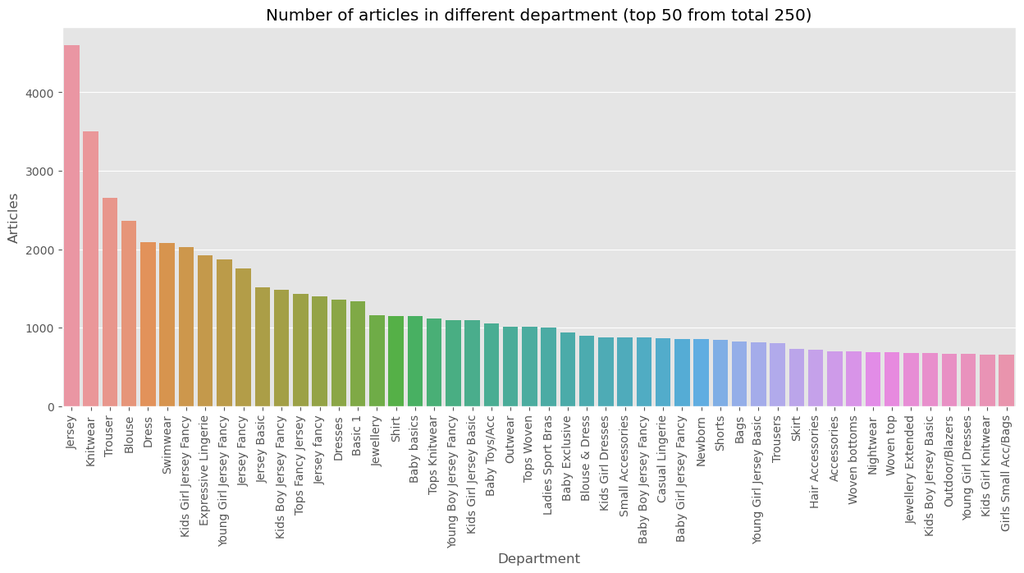

```python
#Take top 50 department

temp = articles_df.groupby(['department_name'])['article_id'].nunique()
df = pd.DataFrame({"Department": temp.index, "Articles": temp.values})
df = df.sort_values(['Articles'], ascending = False).head(50)
plt.figure(figsize = (15,6))
plt.title("Number of articles in different department (top 50 from total 250)")
sns.set_color_codes("pastel")
s = sns.barplot(x = "Department", y = "Articles", data =df)
s.set_xticklabels(s.get_xticklabels(), rotation = 90)
locs, labels = plt.xticks()
plt.show()
```

```python
articles_df.groupby(["department_name"])["product_type_name"].nunique().sort_values(ascending = False)
```

```
department_name
Studio Collection                  39
Take Care External                 38
Baby Exclusive                     36
Conscious Exclusive                33
Jersey                             30
                                   ..
Woven bottoms inactive from S.7     1
Kids Boy Trouser                    1
Jersey inactive from S.6            1
Kids Boy License                    1
Underwear Woven                     1
Name: product_type_name, Length: 250, dtype: int64
```

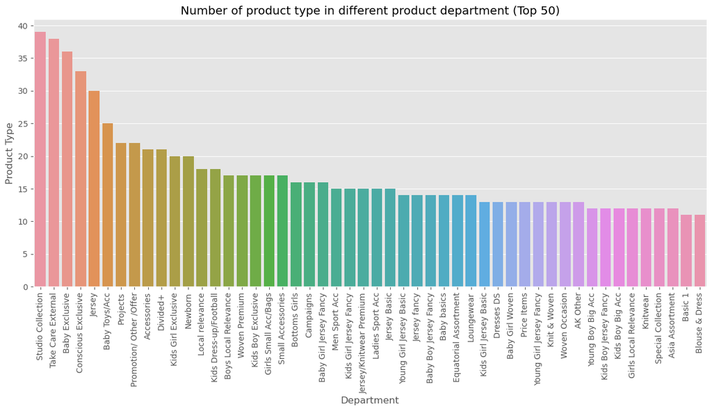

```python
#Lets see the chart on department name and product type

temp = articles_df.groupby(["department_name"])["product_type_name"].nunique()
df = pd.DataFrame({"Department": temp.index, "Product Type": temp.values})
df = df.sort_values(["Product Type"], ascending = False).head(50)
plt.figure(figsize = (15,6))
plt.title("Number of product type in different product department (Top 50)")
sns.set_color_codes("pastel")
s = sns.barplot(x = "Department", y = "Product Type", data = df)
s.set_xticklabels(s.get_xticklabels(), rotation = 90)
locs, labels = plt.xticks()
plt.show()
```

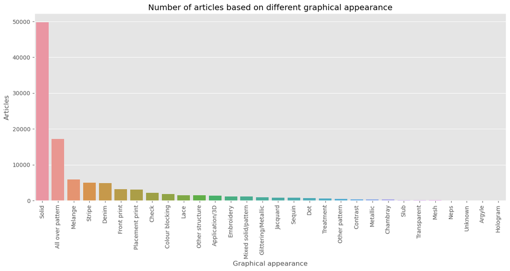

```python
#Lets work on graphical appearance

temp = articles_df.groupby(["graphical_appearance_name"])["article_id"].nunique()
df = pd.DataFrame({"Graphical appearance": temp.index, "Articles": temp.values})
df = df.sort_values(["Articles"], ascending = False)
plt.figure(figsize = (15,6))
plt.title("Number of articles based on different graphical appearance")
sns.set_color_codes("pastel")
s = sns.barplot(x = "Graphical appearance", y = "Articles", data = df)
s.set_xticklabels(s.get_xticklabels(), rotation = 90)
locs, labels = plt.xticks()
plt.show()
```

```python
articles_df.columns
```

```
Index(['article_id', 'product_code', 'prod_name', 'product_type_no',
       'product_type_name', 'product_group_name', 'graphical_appearance_no',
       'graphical_appearance_name', 'colour_group_code', 'colour_group_name',
       'perceived_colour_value_id', 'perceived_colour_value_name',
       'perceived_colour_master_id', 'perceived_colour_master_name',
       'department_no', 'department_name', 'index_code', 'index_name',
       'index_group_no', 'index_group_name', 'section_no', 'section_name',
       'garment_group_no', 'garment_group_name', 'detail_desc'],
      dtype='object')
```

```python
articles_df.groupby(["index_group_name"])["article_id"].nunique().sort_values(ascending = False)
```

```
index_group_name
Ladieswear       39737
Baby/Children    34711
Divided          15149
Menswear         12553
Sport             3392
Name: article_id, dtype: int64
```

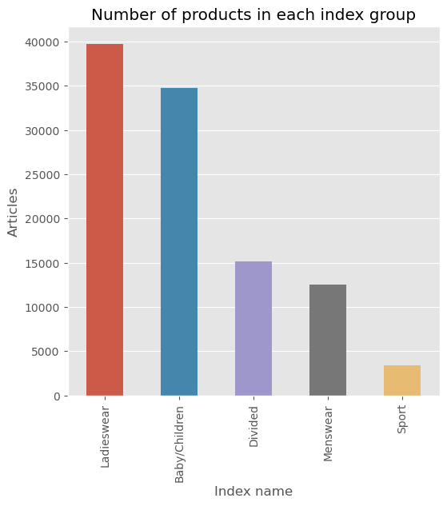

```python
temp = articles_df.groupby(["index_group_name"])["article_id"].nunique()
df = pd.DataFrame({"Index name": temp.index, "Articles": temp.values})
df = df.sort_values(["Articles"], ascending = False)
plt.figure(figsize=(6,6))
plt.title("Number of products in each index group")
sns.set_color_codes("pastel")
s = sns.barplot(x = "Index name", y = "Articles", width = 0.5, data = df)
s.set_xticklabels(s.get_xticklabels(), rotation = 90)
locs, labels = plt.xticks()
plt.show()
```

```python
articles_df.garment_group_name
```

```
0              Jersey Basic
1              Jersey Basic
2              Jersey Basic
3         Under-, Nightwear
4         Under-, Nightwear
                ...
105537     Socks and Tights
105538         Jersey Fancy
105539         Jersey Fancy
105540          Accessories
105541         Jersey Fancy
Name: garment_group_name, Length: 105542, dtype: object
```

```python
articles_df.groupby(["garment_group_name"])["article_id"].nunique().sort_values(ascending = False)
```

```
garment_group_name
Jersey Fancy                     21445
Accessories                      11519
Jersey Basic                      8126
Knitwear                          7490
Under-, Nightwear                 7441
Trousers                          6727
Blouses                           5838
Shoes                             5145
Dresses Ladies                    4874
Outdoor                           4501
Unknown                           3873
Trousers Denim                    3100
Swimwear                          2787
Socks and Tights                  2272
Shirts                            2116
Woven/Jersey/Knitted mix Baby     1965
Shorts                            1559
Dresses/Skirts girls              1541
Skirts                            1254
Special Offers                    1061
Dressed                            908
Name: article_id, dtype: int64
```

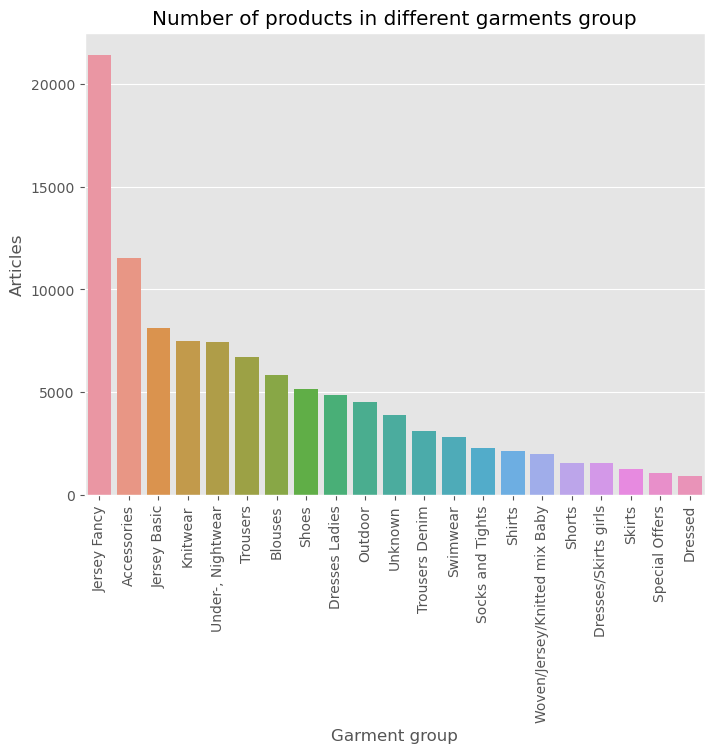

```python
temp = articles_df.groupby(["garment_group_name"])["article_id"].nunique()
df = pd.DataFrame({"Garment group": temp.index, "Articles": temp.values})
df = df.sort_values(["Articles"], ascending = False)
plt.figure(figsize = (8,6))
plt.title("Number of products in different garments group")
sns.set_color_codes("pastel")
s = sns.barplot(x = "Garment group", y = "Articles", data = df)
s.set_xticklabels(s.get_xticklabels(), rotation = 90)
locs, labels = plt.xticks()
plt.show()
```

## Working with Customer Data

```python
customers_df = pd.read_csv(r'E:\Python_2023\H&M\customers.csv')
```

```python
customers_df.head(100)
```

|  | customer_id | FN | Active | club_member_status | fashion_news_frequency | age | postal_code |
| --- | --- | --- | --- | --- | --- | --- | --- |
| 0 | 00000dbacae5abe5e23885899a1fa44253a17956c6d1c3... | NaN | NaN | ACTIVE | NONE | 49.0 | 52043ee2162cf5aa7ee79974281641c6f11a68d276429a... |
| 1 | 0000423b00ade91418cceaf3b26c6af3dd342b51fd051e... | NaN | NaN | ACTIVE | NONE | 25.0 | 2973abc54daa8a5f8ccfe9362140c63247c5eee03f1d93... |
| 2 | 000058a12d5b43e67d225668fa1f8d618c13dc232df0ca... | NaN | NaN | ACTIVE | NONE | 24.0 | 64f17e6a330a85798e4998f62d0930d14db8db1c054af6... |
| 3 | 00005ca1c9ed5f5146b52ac8639a40ca9d57aeff4d1bd2... | NaN | NaN | ACTIVE | NONE | 54.0 | 5d36574f52495e81f019b680c843c443bd343d5ca5b1c2... |
| 4 | 00006413d8573cd20ed7128e53b7b13819fe5cfc2d801f... | 1.0 | 1.0 | ACTIVE | Regularly | 52.0 | 25fa5ddee9aac01b35208d01736e57942317d756b32ddd... |
| ... | ... | ... | ... | ... | ... | ... | ... |
| 95 | 00041bd4c669adc077b6488a2d23ee229a9ad962ab3ee7... | NaN | NaN | PRE-CREATE | NONE | 58.0 | ea731df2fc7625e27cb20ea1a17bb3255ddb125ef35459... |
| 96 | 00045027219e894b683fb4687211e2d0c904c268e9f28d... | NaN | NaN | ACTIVE | NONE | 20.0 | 777fe14eafe75737a8e234db25da1d0e0c5009c3931f02... |
| 97 | 0004518be81f6f0dd216dc5699016bc159ebb9dbd62a76... | NaN | NaN | ACTIVE | NONE | 20.0 | 2c29ae653a9282cce4151bd87643c907644e09541abc28... |
| 98 | 00045b41ba4df7a2e6c09093ec92873ea43a137cf2b24c... | NaN | NaN | ACTIVE | NONE | 18.0 | 2c29ae653a9282cce4151bd87643c907644e09541abc28... |
| 99 | 0004690d2b68d5175697d197a86065595ef7b49c7c051b... | NaN | NaN | PRE-CREATE | NONE | NaN | d831ea0a55a7a7af0e3ff9da0d370e225242bbc7999d78... |

100 rows × 7 columns

- **customer_id** : A unique identifier of every customer
- **FN** : 1 or missed (not clear what it is)
- **Active** : 1 or missed (need to check if it is linked to making purchases)
- **club_member_status** : Status in club
- **fashion_news_frequency** : How often H&M may send news to customer
- **age** : The current age
- **postal_code** : Postal code of customer

```python
missing_data(customers_df)
```

|  | Total | Percent |
| --- | --- | --- |
| Active | 907576 | 66.150819 |
| FN | 895050 | 65.237831 |
| fashion_news_frequency | 16009 | 1.166854 |
| age | 15861 | 1.156066 |
| club_member_status | 6062 | 0.441843 |
| customer_id | 0 | 0.000000 |
| postal_code | 0 | 0.000000 |

```python
def unique_values(data):
    total = data.count()
    tt = pd.DataFrame(total)
    tt.columns = ["Total"]
    uniques = []
    for col in data.columns:
        unique = data[col].nunique()
        uniques.append(unique)
    tt['Uniques'] = uniques
    return tt
```

```python
unique_values(customers_df)
```

|  | Total | Uniques |
| --- | --- | --- |
| customer_id | 1371980 | 1371980 |
| FN | 476930 | 1 |
| Active | 464404 | 1 |
| club_member_status | 1365918 | 3 |
| fashion_news_frequency | 1355971 | 4 |
| age | 1356119 | 84 |
| postal_code | 1371980 | 352899 |

```python
customers_df.club_member_status
```

```
0              ACTIVE
1              ACTIVE
2              ACTIVE
3              ACTIVE
4              ACTIVE
              ...
1371975        ACTIVE
1371976        ACTIVE
1371977        ACTIVE
1371978        ACTIVE
1371979    PRE-CREATE
Name: club_member_status, Length: 1371980, dtype: object
```

```python
customers_df.groupby(["club_member_status"]).nunique()
```

| club_member_status | customer_id | FN | Active | fashion_news_frequency | age | postal_code |
| --- | --- | --- | --- | --- | --- | --- |
| ACTIVE | 1272491 | 1 | 1 | 4 | 84 | 344195 |
| LEFT CLUB | 467 | 1 | 1 | 2 | 56 | 449 |
| PRE-CREATE | 92960 | 1 | 1 | 3 | 82 | 77322 |

```python
customers_df.groupby(["club_member_status"])["customer_id"].nunique()
```

```
club_member_status
ACTIVE        1272491
LEFT CLUB         467
PRE-CREATE      92960
Name: customer_id, dtype: int64
```

```python
customers_df.fashion_news_frequency
```

```
0               NONE
1               NONE
2               NONE
3               NONE
4          Regularly
             ...
1371975         NONE
1371976         NONE
1371977    Regularly
1371978    Regularly
1371979         NONE
Name: fashion_news_frequency, Length: 1371980, dtype: object
```

```python
customers_df.groupby(["fashion_news_frequency"]).nunique()
```

| fashion_news_frequency | customer_id | FN | Active | club_member_status | age | postal_code |
| --- | --- | --- | --- | --- | --- | --- |
| Monthly | 842 | 1 | 1 | 2 | 54 | 827 |
| NONE | 877711 | 1 | 1 | 3 | 84 | 306857 |
| None | 2 | 1 | 1 | 1 | 2 | 2 |
| Regularly | 477416 | 1 | 1 | 3 | 82 | 230891 |

```python
customers_df['fashion_news_frequency'].replace({"None": "NONE"}, inplace = True)
```

```python
customers_df.groupby(["fashion_news_frequency"]).nunique()
```

| fashion_news_frequency | customer_id | FN | Active | club_member_status | age | postal_code |
| --- | --- | --- | --- | --- | --- | --- |
| Monthly | 842 | 1 | 1 | 2 | 54 | 827 |
| NONE | 877713 | 1 | 1 | 3 | 84 | 306859 |
| Regularly | 477416 | 1 | 1 | 3 | 82 | 230891 |

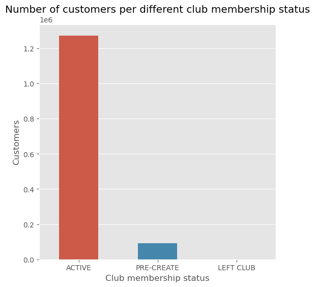

```python
#Let's look into club member status in perspective with customers

temp = customers_df.groupby(["club_member_status"])["customer_id"].nunique()
df = pd.DataFrame({"Club membership status": temp.index, "Customers": temp.values})
df = df.sort_values(["Customers"], ascending = False)
plt.figure(figsize = (6,6))
plt.title("Number of customers per different club membership status")
sns.set_color_codes("pastel")
s = sns.barplot(x = "Club membership status", y = "Customers", width = 0.5, data = df)
s.set_xticklabels(s.get_xticklabels())
locs, labels = plt.xticks()
plt.show()
```

Looks like most of the members are active. lets look what type of age group are active or left.

```python
customers_df.groupby(["club_member_status"])["age"].nunique()
```

```
club_member_status
ACTIVE        84
LEFT CLUB     56
PRE-CREATE    82
Name: age, dtype: int64
```

```python
customers_df.club_member_status.nunique()
```

```
3
```

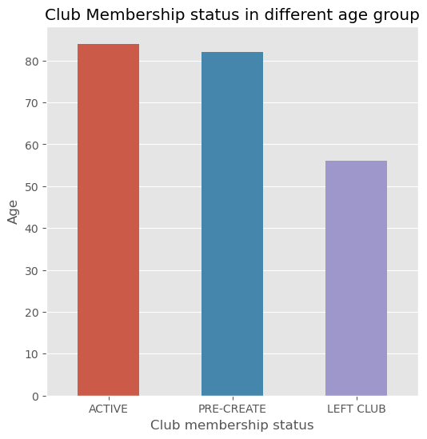

```python
temp = customers_df.groupby(["club_member_status"])["age"].nunique()
df = pd.DataFrame({"Club membership status": temp.index, "Age": temp.values})
df = df.sort_values(["Age"], ascending = False)
plt.figure(figsize = (6,6))
plt.title("Club Membership status in different age group")
sns.set_color_codes("pastel")
s = sns.barplot(x = "Club membership status", y = "Age", width = 0.5, data = df)
s.set_xticklabels(s.get_xticklabels())
locs, labels = plt.xticks()
plt.show()
```